# Caballero Osorio, Fabian - Quiz 2 (Week 5) Feedback

| Course | Assessment |
| --- | --- |
| Machine Learning | Quiz 2 (Week 5) |

| Student Name | Student ID |
| --- | --- |
| Caballero Osorio, Fabian | S3912233 |

### General Assessment Feedback

This quiz was a step up in difficulty from the first quiz, yet the majority of students handled it well. It may be a good idea to have all your notes open before starting the quiz. You will not have time to read through all the notes during the quiz, so please come prepared. If you are not too happy with your mark for this quiz, please keep in mind the lowest quiz mark will be dropped. Overall, as a cohort, we are happy with the overall performance and effort. Great job everyone!

There have been a few questions on the best way to prepare for the quizzes: attending the lectorials and following the computer practice sessions is a good start. Attempting the practice questions yourself beforehand will get you most of the way there for coding/ practical questions as long as you understand each part and how to use and generalise what you have learned to other problems. In terms of theory and concepts, reading the textbook chapters will reinforce the ideas presented during the lectorials.

### Student Assessment Results & Feedback

Question

Student Answer

Correct Answer

Feedback

Score

Question 1, Part (A)  
(link)  
(1 point(s))

Part (A): continuous numerical

Part (A): continuous numerical

*************************  
**STUDENT FEEDBACK:**  
*************************  
**Full credit was awarded for this answer.**  
*************************  
**GENERAL FEEDBACK:**  
*************************  
Weight of a person is a continuous numerical variable.

1.0

Question 1, Part (B)  
(link)  
(1 point(s))

Part (B): nominal categorical

Part (B): nominal categorical

*************************  
**STUDENT FEEDBACK:**  
*************************  
**Full credit was awarded for this answer.**  
*************************  
**GENERAL FEEDBACK:**  
*************************  
Degree codes are in fact nominal categorical variables as there is no natural ordering between these codes.

1.0

Question 1, Part (C)  
(link)  
(1 point(s))

Part (C): discrete numerical

Part (C): discrete numerical

*************************  
**STUDENT FEEDBACK:**  
*************************  
**Full credit was awarded for this answer.**  
*************************  
**GENERAL FEEDBACK:**  
*************************  
Answered correctly by the vast majority of students with number of students in a class being a discrete numerical variable.

1.0

Question 1, Part (D)  
(link)  
(1 point(s))

Part (D): ordinal categorical

Part (D): ordinal categorical

*************************  
**STUDENT FEEDBACK:**  
*************************  
**Full credit was awarded for this answer.**  
*************************  
**GENERAL FEEDBACK:**  
*************************  
Answered correctly by the vast majority of students. The letter grades have a clear hierarchy, and therefore they are ordinal categorical.

1.0

Question 2  
(link)  
(2 point(s))

Answer is (C)

Answer is (C)

*************************  
**STUDENT FEEDBACK:**  
*************************  
**Full credit was awarded for this answer.**  
*************************  
**GENERAL FEEDBACK:**  
*************************  
Answered correctly by the majority of students. Only (C) is a machine learning task. Other choices do not qualify to be machine learning/ predictive modelling.  
A fair coin flip prediction is an interesting one. Regardless of how many historical coin flips you have recorded, even millions of them, the chances for the next coin flip will still be 50/50. This actually underpins a very important concept in machine learning: Yes, we need historical data to train our models, but historical data itself is not enough. There also needs to be a pattern for learning to take place! And this is why many ML projects end up being a failure: Machine learning tasks with no underlying patterns are guaranteed to fail.

2.0

Question 3  
(link)  
(2 point(s))

Restriction bias

restrictive bias

*************************  
**STUDENT FEEDBACK:**  
*************************  
**Full credit was awarded for this answer.**  
*************************  
**GENERAL FEEDBACK:**  
*************************  
Limiting our search space to a particular learning model is called a restrictive bias. However, partial credit was also awarded to inductive bias. Please see Chapter 1 presentation slide #24 for more information.

2.0

Question 4  
(link)  
(2 point(s))

Balancing underfitting vs. overfitting

Balancing underfitting vs. overfitting

*************************  
**STUDENT FEEDBACK:**  
*************************  
**Full credit was awarded for this answer.**  
*************************  
**GENERAL FEEDBACK:**  
*************************  
The hardest part of ML is to figure out the optimal trade-off between bias and variance, that is, balancing underfitting vs. overfitting. However, cleaning the data for modeling is also an issue sometimes, so partial credit was given to this answer as well.

2.0

Question 5  
(link)  
(2 point(s))

Model interpretation

Model interpretation

*************************  
**STUDENT FEEDBACK:**  
*************************  
**Full credit was awarded for this answer.**  
*************************  
**GENERAL FEEDBACK:**  
*************************  
The majority of students answered this correctly. Model interpretation is not part of CRISP-DM.

2.0

Question 6  
(link)  
(2 point(s))

less variance, higher bias

less variance, higher bias

*************************  
**STUDENT FEEDBACK:**  
*************************  
**Full credit was awarded for this answer.**  
*************************  
**GENERAL FEEDBACK:**  
*************************  
A KNN model with K=5 has less variance compared to K=1 as averaging over the nearest 5 neighbors reduces the variance. On the other hand, this averaging also results in higher bias. Please see Chapter 1 presentation slides #34 and #35 for more information.

2.0

Question 7  
(link)  
(4 point(s))

```
import numpy as np

lower = int(float(input('Waiting for input: ')))
upper = int(float(input('Waiting for input: ')))

def function1(lower, upper):

    ### ADD YOUR CODE BELOW
    if lower <35 and upper <35:
        if lower % 2:
            A = np.arange(lower+1,upper+1,2)
        else:
            A = np.arange(lower,upper+1,2)

        result = A.mean()
    else:
        return 0


        return result

    ### ADD YOUR CODE ABOVE

print(f"The mean is {function1(lower, upper):.2f}.")

UNIT TEST RESULTS:
Test 1: Failed. (Test did not execute successfully)

Test 2: Failed. (Test did not execute successfully)

Test 3: Failed. (Unsuccessful Test Output: The mean is 0.00.)

Test 4: Failed. (Unsuccessful Test Output: The mean is 0.00.)
```

```
import numpy as np

lower = int(float(input('Waiting for input: ')))
upper = int(float(input('Waiting for input: ')))

def function1(lower, upper):

    ### ADD YOUR CODE BELOW
    if lower % 2 == 1:
        lower = lower + 1

    if upper % 2 == 1:
        upper = upper - 1

    array_range = np.arange(lower, upper+1, step = 2)
    array_range_filtered = array_range[array_range < 35]
    result = array_range_filtered.mean()

    # result = 999

    return result

    ### ADD YOUR CODE ABOVE

print(f"The mean is {function1(lower, upper):.2f}.")
```

*************************  
**STUDENT FEEDBACK:**  
*************************  
**No credit was awarded for this answer.**  
*************************  
**GENERAL FEEDBACK:**  
*************************  
This question was handled well by a large number of students, others however need to read the question carefully to notice that the use of for loops was not allowed. The intention of this was to assess your Numpy abilities and there were 2 boxes to tick for this question: 1. the arange() function and 2. array conditions. The arange() function is similar to the inbuilt range function, however it creates a numpy array rather than a list/ range object. The condition for the array creates a boolean index (sometimes called a mask) and is used to index the elements in the array.  
Common mistakes included forgetting range stops one before the upper bound and incorrect conditions.

0.0

Question 8  
(link)  
(1 point(s))

```
import pandas as pd

df = pd.read_csv("icecream.csv")

### ADD YOUR CODE BELOW


unique_ages = df['age'].nunique()

### ADD YOUR CODE ABOVE

print(f"There are {unique_ages} unique ages.")

OUTPUT:
There are 30 unique ages.
```

```
import pandas as pd

df = pd.read_csv("icecream.csv")

### ADD YOUR CODE BELOW

unique_ages = df['age'].nunique()

# unique_ages = 999

### ADD YOUR CODE ABOVE

print(f"There are {unique_ages} unique ages.")

OUTPUT:
There are 30 unique ages.
```

*************************  
**STUDENT FEEDBACK:**  
*************************  
**Full credit was awarded for this answer.**  
*************************  
**GENERAL FEEDBACK:**  
*************************  
This question was answered correctly by the vast majority of students.

1.0

Question 9  
(link)  
(1 point(s))

```
import pandas as pd

df = pd.read_csv("icecream.csv")

### ADD YOUR CODE BELOW


median_age = df['age'].median()

### ADD YOUR CODE ABOVE

print(f"The median age of customers is {median_age}.")

OUTPUT:
The median age of customers is 22.0.
```

```
import pandas as pd

df = pd.read_csv("icecream.csv")

### ADD YOUR CODE BELOW

median_age = df['age'].median()

# median_age = 999

### ADD YOUR CODE ABOVE

print(f"The median age of customers is {median_age}.")

OUTPUT:
The median age of customers is 22.0.
```

*************************  
**STUDENT FEEDBACK:**  
*************************  
**Full credit was awarded for this answer.**  
*************************  
**GENERAL FEEDBACK:**  
*************************  
Answered correctly by the vast majority of students.

1.0

Question 10  
(link)  
(3 point(s))

```
import pandas as pd

customerID = int(float(input('Waiting for input: ')))  # example: 101

df = pd.read_csv("icecream.csv")

### ADD YOUR CODE BELOW


customer_age = df[['age'],['ID'==customerID]]

order = df[['scoop_1',['ID'==customerID]]

### ADD YOUR CODE ABOVE

print(f"customer age is {customer_age} and their first scoop flavour is {order}.")

UNIT TEST RESULTS:
Test 1: Failed. (Test did not execute successfully)

Test 2: Failed. (Test did not execute successfully)
```

```
import pandas as pd

customerID = int(float(input('Waiting for input: ')))  # example: 101

df = pd.read_csv("icecream.csv")

### ADD YOUR CODE BELOW

df_filtered = df[df['ID'] == customerID]

order_cell = df_filtered['scoop_1'].iloc[0]
order = str(order_cell)

age_cell = df_filtered['age'].iloc[0]
customer_age = int(age_cell)

# customer_age = 999
# order = 999

### ADD YOUR CODE ABOVE

print(f"customer age is {customer_age} and their first scoop flavour is {order}.")
```

*************************  
**STUDENT FEEDBACK:**  
*************************  
**No credit was awarded for this answer.**  
*************************  
**GENERAL FEEDBACK:**  
*************************  
This was handled well by the majority of students who attempted it. We expect that the outputs are exclusively the required value/ object requested. For instance, students who provided a list or array rather than an integer for customer_age were not awarded any credit.

0.0

Question 11  
(link)  
(4 point(s))

```
import pandas as pd

delivery_method = str(input('Waiting for input: '))  #example: scoop_1

df = pd.read_csv("icecream.csv")

### ADD YOUR CODE BELOW


youngest_age = df['age'].min
oldest_age = df['age'].max

### ADD YOUR CODE ABOVE

print(f"Youngest: {youngest_age}, oldest: {oldest_age}")
```

[output cut: 82 more lines]

```
import pandas as pd

delivery_method = str(input('Waiting for input: '))  #example: scoop_1

df = pd.read_csv("icecream.csv")

### ADD YOUR CODE BELOW

df['topping'] = df['topping'].replace({'choc-chips': 'chocchips'})

df_filtered = df[(df['delivery'] == delivery_method) &
                 (df['topping'] == 'chocchips')]

youngest_age = df_filtered['age'].min()
oldest_age = df_filtered['age'].max()

# youngest_age = 999
# oldest_age = 999

### ADD YOUR CODE ABOVE

print(f"Youngest: {youngest_age}, oldest: {oldest_age}")
```

*************************  
**STUDENT FEEDBACK:**  
*************************  
**No credit was awarded for this answer.**  
*************************  
**GENERAL FEEDBACK:**  
*************************  
This was handled well by the majority of students who attempted it. Some students used additional conditions during subsetting to achieve the correct result, this is fine for once off queries (like this quiz) however in practice it is a good idea to correct the values before querying. Common mistakes included forgetting to account for the two different recordings of chocchips or incorrect conditions for the subsets.  
**Please Note:** The first unit test for this question, **Test 1**, was marked a bit more leniently than the other tests. Specifically, your code passed the first test even if it was not 100% correct, but had reasonable outputs. The reason for that was to award some partial credit to students who knew how to use the min() and max() functions.

0.0

Question 12  
(link)  
(3 point(s))

```
import pandas as pd

age_threshold = int(input('Waiting for input: '))  #example: 10

df = pd.read_csv("icecream.csv")

### ADD YOUR CODE BELOW


double_scoopers = 999

### ADD YOUR CODE ABOVE

print(f"The number of orders with two scoops of the same flavour and over the age threshold is {double_scoopers}.")

UNIT TEST RESULTS:
Test 1: Failed. (Unsuccessful Test Output: The number of orders with two scoops of the same flavour and over the age threshold is 999.)

Test 2: Failed. (Unsuccessful Test Output: The number of orders with two scoops of the same flavour and over the age threshold is 999.)

Test 3: Failed. (Unsuccessful Test Output: The number of orders with two scoops of the same flavour and over the age threshold is 999.)
```

```
import pandas as pd

age_threshold = int(input('Waiting for input: '))  #example: 10

df = pd.read_csv("icecream.csv")

### ADD YOUR CODE BELOW

double_scoop = pd.DataFrame([])

# loop over all avaliable flavours
for flavour in df['scoop_1'].unique():

    # search across all combinations of scoops
    for index1 in range(1,4):
        for index2 in range(index1+1,4):

            # subset to obtain double scoops and add to cumalative dataframe
            temp = df[(df['scoop_'+str(index1)] == flavour) & (df['scoop_'+str(index2)] == flavour)]
            double_scoop = pd.concat([double_scoop,temp])

# Remove repeated entries
double_scoop = double_scoop.groupby(double_scoop.index).first()

# final subset by age and get the number of rows
double_scoopers = double_scoop[double_scoop['age'] > age_threshold].shape[0]

# double_scoopers = 999

### ADD YOUR CODE ABOVE

print(f"The number of orders with two scoops of the same flavour and over the age threshold is {double_scoopers}.")
```

*************************  
**STUDENT FEEDBACK:**  
*************************  
**No credit was awarded for this answer.**  
*************************  
**GENERAL FEEDBACK:**  
*************************  
Only a handful of students got this question correct. To those who did, we applaud you! If not, please feel free to attempt this yourself at your own pace for a practice in data manipulation with Python and Pandas.

0.0

TOTAL: 16.0/30

### Assessment Unit Tests

| Question | Test Name | Test Weight | Test Input | Required Test Output |
| --- | --- | --- | --- | --- |
| Question 7 | Test 1 | 1 | 23; 30 | The mean is 27.00. |
| Question 7 | Test 2 | 1 | 24; 30 | The mean is 27.00. |
| Question 7 | Test 3 | 1 | 13; 45 | The mean is 24.00. |
| Question 7 | Test 4 | 1 | 14;45 | The mean is 24.00. |
| Question 10 | Test 1 | 1 | 135 | Customer age is 5 and their first scoop flavour is vanilla. |
| Question 10 | Test 2 | 2 | 140 | Customer age is 6 and their first scoop flavour is strawberry. |
| Question 11 | Test 1 | 1 | cup | Youngest: 7, oldest: 83 |
| Question 11 | Test 2 | 1 | cone | Youngest: 6, oldest: 61 |
| Question 11 | Test 3 | 2 | waffle | Youngest: 12, oldest: 83 |
| Question 12 | Test 1 | 1 | 10 | The number of orders with two scoops of the same flavour and over the age threshold is 22. |
| Question 12 | Test 2 | 1 | 32 | The number of orders with two scoops of the same flavour and over the age threshold is 9. |
| Question 12 | Test 3 | 1 | 5 | The number of orders with two scoops of the same flavour and over the age threshold is 29. |

### Assessment Scores Histogram

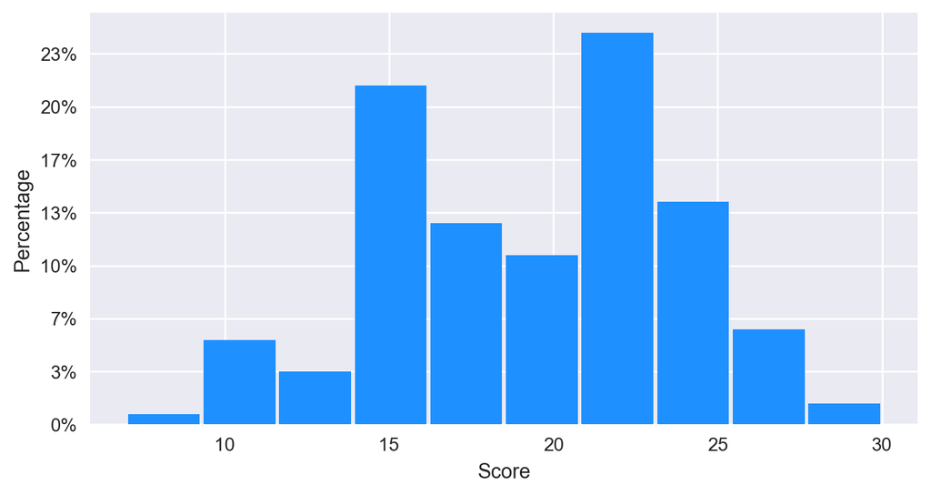

## Assessment Questions

**CODE OF CONDUCT**

- **Use of ChatGPT or similar AI tools is STRICTLY FORBIDDEN in our bi-weekly quizzes.**
- This is a "**limited open-computer**" assessment.
- **You must work on this assessment on your own and you must neither provide nor receive any help from anyone.**
- **You must not share this questions notebook nor your solutions with anyone, neither before submission nor after.**
- Please see Canvas for the full `Code of Conduct`.

**INSTRUCTIONS**

1. You **must not** delete any existing cells in this notebook and you **must not** modify any existing cell tags. If you accidentally delete a cell, you will need to go to the "Edit" menu option and select "Undo Delete Cells".
2. In an answer cell, any direct action **required from you** will be indicated by UPPER CASE PYTHON COMMENTS starting with "###".
3. In general, the value of "999" will denote a dummy placeholder.
4. You **must not change even a single character** in an existing code cell that is **outside** of the "ADD YOUR CODE BELOW/ ABOVE" block.
5. You **must not** have any additional print() statement outputs of your own for any question in your submission.
6. You **must** run each and every one of your answer cells so that your answers are recorded correctly for marking purposes.
7. Please keep in mind that, if you select "*Restart & Clear Output*" or "*Restart & Run All*" from the "*Kernel*" menu option, your answers for any multiple-choice questions will reset to "**nothing selected**".
8. Please see Canvas for additional assessment instructions.
9. This assessment has 12 questions for a total of 30 points.
10. Good luck!

```python
### PLEASE RUN THIS CELL SO THAT THE DROPDOWN ANSWER SELECTIONS BELOW WORK CORRECTLY
### WARNING!! If you restart your kernel, you will need to run this cell again.
from ipywidgets import interactive
def function_mcq(selection): pass
```

```python
### PLEASE FIRST WRITE YOUR FULL NAME AND STUDENT ID BELOW,
### AND THEN EXECUTE THIS CODE CELL.
# Thank you.
print("""
Name:
Student ID:
""")
```

## Question 1 (4 points)

Identify the following variables as either **discrete numerical**, **continuous numerical**, **nominal categorical**, or **ordinal categorical**:

- **Part (A)** RMIT students' weights
- **Part (B)** RMIT STEM College master's degree program codes
- **Part (C)** Number of RMIT students in a class
- **Part (D)** RMIT letter grades for this course

```python
### PLEASE RUN THIS CELL
q1a = interactive(function_mcq,
                 selection=['Part (A): nothing selected',
                            'Part (A): discrete numerical',
                            'Part (A): continuous numerical',
                            'Part (A): nominal categorical',
                            'Part (A): ordinal categorical']);

q1b = interactive(function_mcq,
                 selection=['Part (B): nothing selected',
                            'Part (B): discrete numerical',
                            'Part (B): continuous numerical',
                            'Part (B): nominal categorical',
                            'Part (B): ordinal categorical']);

q1c = interactive(function_mcq,
                 selection=['Part (C): nothing selected',
                            'Part (C): discrete numerical',
                            'Part (C): continuous numerical',
                            'Part (C): nominal categorical',
                            'Part (C): ordinal categorical']);

q1d = interactive(function_mcq,
                 selection=['Part (D): nothing selected',
                            'Part (D): discrete numerical',
                            'Part (D): continuous numerical',
                            'Part (D): nominal categorical',
                            'Part (D): ordinal categorical']);

display(q1a)
display(q1b)
display(q1c)
display(q1d)
```

```python
### PLEASE RUN THIS CELL AFTER YOUR SELECTION ABOVE
print(f"{q1a.kwargs['selection']}")
```

```python
### PLEASE RUN THIS CELL AFTER YOUR SELECTION ABOVE
print(f"{q1b.kwargs['selection']}")
```

```python
### PLEASE RUN THIS CELL AFTER YOUR SELECTION ABOVE
print(f"{q1c.kwargs['selection']}")
```

```python
### PLEASE RUN THIS CELL AFTER YOUR SELECTION ABOVE
print(f"{q1d.kwargs['selection']}")
```

**Go to Top**

## Question 2 (2 points)

Which one of the following is a machine learning task?

- (A) Grouping customers based on their city of residence and finding the mean customer income per city
- (B) Dividing customers according to their profitability
- (C) Predicting the future stock price of a company using historical data
- (D) Predicting the outcome of a fair coin flip
- (E) Finding the highest earning customers in a dataset

```python
### PLEASE RUN THIS CELL
q2 = interactive(function_mcq,
                 selection=['nothing selected',
                 'Answer is (A)',
                 'Answer is (B)',
                 'Answer is (C)',
                 'Answer is (D)',
                 'Answer is (E)']);
display(q2)
```

```python
### PLEASE RUN THIS CELL AFTER YOUR SELECTION ABOVE
print(f"{q2.kwargs['selection']}")
```

**Go to Top**

## Question 3 (2 points)

Ella works as a data scientist with a telco company and she is currently building a machine learning model for predicting customer churn. She decides to use a Nearest Neighbour machine learning model for this task. What is this bias called? **Please limit your answer to two words and make sure the second word is "bias".**

```python
# PROVIDE YOUR ANSWER INSIDE THE `print()` STATEMENT BELOW
# AND THEN RUN THIS CELL
print("""

""")
```

**Go to Top**

## Question 4 (2 points)

Consider the lectorial presentation on Chapter 1: ML Basics. What is the hardest part of machine learning?

```python
### PLEASE RUN THIS CELL
q4 = interactive(function_mcq,
                 selection=['nothing selected',
                 'Cleaning the data for modeling',
                 'Encoding of descriptive features ',
                 'Balancing underfitting vs. overfitting ',
                 'Hyper-parameter fine tuning',
                 'Choosing the correct performance metric  ']);
display(q4)
```

```python
### PLEASE RUN THIS CELL AFTER YOUR SELECTION ABOVE
print(f"{q4.kwargs['selection']}")
```

**Go to Top**

## Question 5 (2 points)

**CRISP-DM** (Cross-Industry Standard Process for Data Mining) is a very useful model for describing the PDA (Predictive Data Analytics) project life-cycle. Which one of the following phases is **not** part of CRISP-DM?

```python
### PLEASE RUN THIS CELL
q5 = interactive(function_mcq,
                 selection=['nothing selected',
                 'Data understanding ',
                 'Predictive modeling ',
                 'Model evaluation',
                 'Data preparation ',
                 'Business understanding  ',
                 'Model interpretation']);
display(q5)
```

```python
### PLEASE RUN THIS CELL AFTER YOUR SELECTION ABOVE
print(f"{q5.kwargs['selection']}")
```

**Go to Top**

Consider a K-Nearest Neighbour (KNN) model with `K=5` for a particular machine learning task. What can be said about this model when compared to a KNN model with `K=1` for the same task?

```python
### PLEASE RUN THIS CELL
q6 = interactive(function_mcq,
                 selection=['nothing selected',
                 'higher variance, less bias ',
                 'less variance, higher bias ',
                 'less variance, less bias',
                 'higher variance, higher bias ']);
display(q6)
```

```python
### PLEASE RUN THIS CELL AFTER YOUR SELECTION ABOVE
print(f"{q6.kwargs['selection']}")
```

**Go to Top**

## Question 7 (4 points)

Write a Python program that will ask for two positive integers as lower and upper bounds respectively and print the mean of all the **even integers** between these two integers (both inclusive) **that are strictly smaller than 35**.

For example, for the inputs of `23` and `30`, your program needs to output `27.00`.

**CLARIFICATION:** You do **NOT** need to check for validity of the user inputs.

**NOTE:** Loops are not allowed in this question. That is, your code **MAY NOT** contain the string "for".

```python
import numpy as np

lower = int(float(input('Waiting for input: ')))
upper = int(float(input('Waiting for input: ')))

def function1(lower, upper):

    ### ADD YOUR CODE BELOW


    result = 999

    return result

    ### ADD YOUR CODE ABOVE

print(f"The mean is {function1(lower, upper):.2f}.")
```

**Go to Top**

### For Questions 8 to 12:

You will be working with the `icecream.csv` CSV dataset file. You can find this CSV file inside the Canvas Quiz page where you downloaded this Questions notebook.

**WARNING 1:** You **MUST** make sure that your Jupyter notebook and this CSV file are in the same folder or your programs will **NOT** pass our automated unit tests. If you are on Google Colab, you **MUST** upload this CSV file under the session storage at the root level. Please see the bottom of [this page](https://rmit.instructure.com/courses/106983/pages/jupyter-notebooks-on-the-cloud-google-colab) for more information.

**WARNING 2 (Mac OS Safari Issue):** In some cases, if you are on Mac OS using Safari, you might run into "Unauthorised" error while trying to download a CSV file within a Canvas quiz page. If this is the case for you, please avoid using the Safari browser and try another browser.

Please first run the code cell below for practice so that you can see what this dataset looks like.

This dataset catalogs the orders from an ice cream shop which serves chocolate, vanilla and strawberry flavoured ice cream (up to 3 scoops of any flavour), additional toppings and how the order was delivered. Alongside the order, the customers age is also recorded.

The features are described as follows:

- `ID`: the customer ID
- `age`: the customers age
- `scoop_1`: the flavour of the first scoop
- `scoop_2`: the flavour of the second scoop, may be None
- `scoop_3`: the flavour of the third scoop, may be None
- `topping`: the topping
- `delivery`: placed into a cup, cone or waffle

```python
import pandas as pd

df = pd.read_csv("icecream.csv")

df.head()
```

|  | ID | age | scoop_1 | scoop_2 | scoop_3 | topping | delivery |
| --- | --- | --- | --- | --- | --- | --- | --- |
| 0 | 101 | 22 | chocolate | chocolate | None | choc-chips | cup |
| 1 | 102 | 47 | chocolate | vanilla | None | None | waffle |
| 2 | 103 | 5 | vanilla | chocolate | strawberry | sprinkles | cone |
| 3 | 104 | 12 | chocolate | chocolate | None | chocchips | waffle |
| 4 | 105 | 10 | vanilla | strawberry | vanilla | choc-chips | cup |

**Go to Top**

## Question 8 (1 point)

Write a python program that calculates the number of unique ages in the dataset.

```python
import pandas as pd

df = pd.read_csv("icecream.csv")

### ADD YOUR CODE BELOW


unique_ages = 999

### ADD YOUR CODE ABOVE

print(f"There are {unique_ages} unique ages.")
```

**Go to Top**

## Question 9 (1 point)

Write a Python program that calculates the median age of customers.

```python
import pandas as pd

df = pd.read_csv("icecream.csv")

### ADD YOUR CODE BELOW


median_age = 999

### ADD YOUR CODE ABOVE

print(f"The median age of customers is {median_age}.")
```

**Go to Top**

## Question 10 (3 points)

Write a program that will first ask for an ID, and then print this customer's age as well as the flavour of the first scoop.

For example, for the inputs of `101`, your program needs to print `customer age is 22 and their first scoop flavour is chocolate`.

```python
import pandas as pd

customerID = int(float(input('Waiting for input: ')))  # example: 101

df = pd.read_csv("icecream.csv")

### ADD YOUR CODE BELOW



customer_age = 999
order = 999

### ADD YOUR CODE ABOVE

print(f"customer age is {customer_age} and their first scoop flavour is {order}.")
```

**Go to Top**

## Question 11 (4 points)

Write a program that will first ask for a delivery method, and then print the age of the youngest and oldest customer for which the following two conditions hold:

1. The icecream was served in the requested delivery method (cup, cone, or waffle)
2. They have the choc chips topping.

**NOTE:** The `topping` feature in this dataset has two different values for choc chips: `chocchips` and `choc-chips`.

```python
import pandas as pd

delivery_method = str(input('Waiting for input: '))  #example: scoop_1

df = pd.read_csv("icecream.csv")

### ADD YOUR CODE BELOW


youngest_age = 999
oldest_age = 999

### ADD YOUR CODE ABOVE

print(f"Youngest: {youngest_age}, oldest: {oldest_age}")
```

**Go to Top**

## Question 12: Challenge Question (3 points)

**This is a Challenge Question, please only attempt this question AFTER the rest of the questions!**

**Also be aware of how much time you have left!**

Write a program that reports the number of sales to customers over a given age in which they order two scoops of the same flavour of icecream in any scoop order.

**Hint**: The strings `scoop_1` and `scoop_2` can also be constructed as `'scoop_'+str(1)` and `'scoop_'+str(2)` respectively.

```python
import pandas as pd

age_threshold = int(input('Waiting for input: '))  #example: 10

df = pd.read_csv("icecream.csv")

### ADD YOUR CODE BELOW


double_scoopers = 999

### ADD YOUR CODE ABOVE

print(f"The number of orders with two scoops of the same flavour and over the age threshold is {double_scoopers}.")
```

**Go to Top**

Marking & Feedback by **[SageGrader.com](https://sagegrader.com)**: The Sage Way To Grade.